# 02 Análise Exploratória

pedro-hos@outlook.com

5/3/2022

```r
library("PerformanceAnalytics")
```

```r
library("corrplot")
library("ggpubr")
library("ggplot2")
```

Os seguinte arquivos foram carregados:

- todos_anos.RData: contendo os dados para todos os períodos;
- anos_iniciais.RData: contendo os anos iniciais do ensino fundamental, ou seja de 1º ao 6º ano;
- anos_finais.RData: contendo os anos finais do ensino fundamental, ou seja de 7º ao 9º ano;
- ensino_medio.RData: contendo os dados para o ensino médio, do 1º do ensino médio ao 3º do ensino médio. *ideb_media.RData: Média das notas do Ideb para os três periodos, respeitando os anos da aplicação e os municípios

```r
load(file = "../../data/ideb_repasse/todos_anos.RData")
load(file = "../../data/ideb_repasse/anos_iniciais.RData")
load(file = "../../data/ideb_repasse/anos_finais.RData")
load(file = "../../data/ideb_repasse/ensino_medio.RData")
load(file = "../../data/ideb_repasse/ideb_media.RData")
```

As colunas para todos os períodos se mantém a mesma, como podemos ver a seguir:

```r
colnames(ideb_repasse)
```

```
##  [1] "ANO_IDEB"                 "ANO_IDH"
##  [3] "ANO_REPASSE"              "IDEB_NOTA"
##  [5] "IDHM"                     "IDH_EDUCACAO"
##  [7] "IDH_LONGEVIDADE"          "IDH_RENDA"
##  [9] "MUNICIPIO"                "PERIODO"
## [11] "POPULACAO"                "REDE"
## [13] "UF"                       "VALOR_REPASSADO_EDUCACAO"
```

E também possuem a seguinte estrutura, com variáveis nominais, como o caso da coluna **PERIODO** e valores contínuos como o caso de **IDEB_NOTA**:

```r
dplyr::glimpse(ideb_repasse)
```

```
## Rows: 62,612
## Columns: 14
## $ ANO_IDEB                 <fct> 2011, 2013, 2015, 2017, 2019, 2011, 2013, 201…
## $ ANO_IDH                  <fct> 2010, 2010, 2010, 2010, 2010, 2010, 2010, 201…
## $ ANO_REPASSE              <fct> 2012, 2014, 2016, 2018, 2020, 2012, 2014, 201…
## $ IDEB_NOTA                <dbl> 4.3, 5.4, 5.8, 6.2, 5.7, 4.6, 4.9, 5.2, 5.5, …
## $ IDHM                     <dbl> 0.641, 0.641, 0.641, 0.641, 0.641, 0.702, 0.7…
## $ IDH_EDUCACAO             <dbl> 0.526, 0.526, 0.526, 0.526, 0.526, 0.600, 0.6…
## $ IDH_LONGEVIDADE          <dbl> 0.763, 0.763, 0.763, 0.763, 0.763, 0.806, 0.8…
## $ IDH_RENDA                <dbl> 0.641, 0.641, 0.641, 0.641, 0.641, 0.702, 0.7…
## $ MUNICIPIO                <fct> Alta Floresta D'Oeste, Alta Floresta D'Oeste,…
## $ PERIODO                  <fct> FUNDAMENTAL_ANOS_INICIAIS, FUNDAMENTAL_ANOS_I…
## $ POPULACAO                <int> 0, 0, 0, 0, 0, 0, 0, 0, 0, 0, 0, 0, 0, 0, 0, …
## $ REDE                     <fct> Pública, Pública, Pública, Pública, Pública, …
## $ UF                       <fct> RO, RO, RO, RO, RO, RO, RO, RO, RO, RO, RO, R…
## $ VALOR_REPASSADO_EDUCACAO <dbl> 4452207.0, 4565930.3, 6059865.4, 5127457.4, 4…
```

Os anos das notas do IDEB para os anos iniciais e finais variam de 2011 à 2019, e os valores do repasse foram coletados sempre respeitando **ANO_IDEB + 1**, ou seja, os repasses de 2012 são para o ano da aplicação do Ideb de 2011, e assim por diante. Os indicadores de IDH são os últimos coletados, em 2010.

- Anos Iniciais

```r
summary(anos_iniciais)
```

```
##  ANO_IDEB    ANO_IDH      ANO_REPASSE   IDEB_NOTA          IDHM
##  2011:5155   2010:26342   2012:5155   Min.   :2.300   Min.   :0.4180
##  2013:5229                2014:5229   1st Qu.:4.500   1st Qu.:0.5990
##  2015:5209                2016:5209   Median :5.400   Median :0.6640
##  2017:5405                2018:5405   Mean   :5.316   Mean   :0.6586
##  2019:5344                2020:5344   3rd Qu.:6.100   3rd Qu.:0.7170
##                                       Max.   :9.400   Max.   :0.8620
##
##   IDH_EDUCACAO    IDH_LONGEVIDADE   IDH_RENDA              MUNICIPIO
##  Min.   :0.2070   Min.   :0.672   Min.   :0.4180   Bom Jesus    :   25
##  1st Qu.:0.4890   1st Qu.:0.769   1st Qu.:0.5990   Planalto     :   20
##  Median :0.5600   Median :0.807   Median :0.6640   Santa Helena :   20
##  Mean   :0.5589   Mean   :0.801   Mean   :0.6586   Santa Luzia  :   20
##  3rd Qu.:0.6310   3rd Qu.:0.835   3rd Qu.:0.7170   São Domingos :   20
##  Max.   :0.8250   Max.   :0.894   Max.   :0.8620   São Francisco:   20
##                                                    (Other)      :26217
##                       PERIODO        POPULACAO      REDE             UF
##  ENSINO_MEDIO             :    0   Min.   :0   Pública:26342   MG     : 4121
##  FUNDAMENTAL_ANOS_FINAIS  :    0   1st Qu.:0                   SP     : 3117
##  FUNDAMENTAL_ANOS_INICIAIS:26342   Median :0                   BA     : 2045
##                                    Mean   :0                   RS     : 1953
##                                    3rd Qu.:0                   PR     : 1935
##                                    Max.   :0                   SC     : 1349
##                                                                (Other):11822
##  VALOR_REPASSADO_EDUCACAO
##  Min.   :3.764e+04
##  1st Qu.:9.650e+05
##  Median :2.507e+06
##  Mean   :9.097e+06
##  3rd Qu.:6.908e+06
##  Max.   :2.033e+10
##
```

- Anos Finais

```r
summary(anos_finais)
```

```
##  ANO_IDEB    ANO_IDH      ANO_REPASSE   IDEB_NOTA          IDHM
##  2011:5284   2010:26351   2012:5284   Min.   :1.500   Min.   :0.4180
##  2013:5304                2014:5304   1st Qu.:3.600   1st Qu.:0.5990
##  2015:5164                2016:5164   Median :4.300   Median :0.6650
##  2017:5387                2018:5387   Mean   :4.235   Mean   :0.6593
##  2019:5212                2020:5212   3rd Qu.:4.800   3rd Qu.:0.7180
##                                       Max.   :7.800   Max.   :0.8620
##
##   IDH_EDUCACAO    IDH_LONGEVIDADE    IDH_RENDA              MUNICIPIO
##  Min.   :0.2070   Min.   :0.6720   Min.   :0.4180   Bom Jesus    :   25
##  1st Qu.:0.4900   1st Qu.:0.7690   1st Qu.:0.5990   Planalto     :   20
##  Median :0.5610   Median :0.8080   Median :0.6650   São Domingos :   20
##  Mean   :0.5596   Mean   :0.8015   Mean   :0.6593   São Francisco:   20
##  3rd Qu.:0.6310   3rd Qu.:0.8360   3rd Qu.:0.7180   Vera Cruz    :   20
##  Max.   :0.8250   Max.   :0.8940   Max.   :0.8620   Bonito       :   19
##                                                     (Other)      :26227
##                       PERIODO        POPULACAO      REDE             UF
##  ENSINO_MEDIO             :    0   Min.   :0   Pública:26351   MG     : 4136
##  FUNDAMENTAL_ANOS_FINAIS  :26351   1st Qu.:0                   SP     : 3134
##  FUNDAMENTAL_ANOS_INICIAIS:    0   Median :0                   RS     : 2050
##                                    Mean   :0                   BA     : 1995
##                                    3rd Qu.:0                   PR     : 1940
##                                    Max.   :0                   SC     : 1380
##                                                                (Other):11716
##  VALOR_REPASSADO_EDUCACAO
##  Min.   :3.764e+04
##  1st Qu.:9.415e+05
##  Median :2.459e+06
##  Mean   :9.044e+06
##  3rd Qu.:6.818e+06
##  Max.   :2.033e+10
##
```

Já para o Ensino Médio, os anos são de 2017 e 2019.

```r
summary(ensino_medio)
```

```
##  ANO_IDEB    ANO_IDH     ANO_REPASSE   IDEB_NOTA          IDHM
##  2011:   0   2010:9919   2012:   0   Min.   :1.500   Min.   :0.4430
##  2013:   0               2014:   0   1st Qu.:3.300   1st Qu.:0.5990
##  2015:   0               2016:   0   Median :3.800   Median :0.6640
##  2017:5206               2018:5206   Mean   :3.789   Mean   :0.6587
##  2019:4713               2020:4713   3rd Qu.:4.300   3rd Qu.:0.7180
##                                      Max.   :6.500   Max.   :0.8620
##
##   IDH_EDUCACAO    IDH_LONGEVIDADE    IDH_RENDA              MUNICIPIO
##  Min.   :0.2340   Min.   :0.6720   Min.   :0.4430   Bom Jesus    :   8
##  1st Qu.:0.4890   1st Qu.:0.7680   1st Qu.:0.5990   Bonito       :   8
##  Median :0.5600   Median :0.8070   Median :0.6640   Santa Luzia  :   8
##  Mean   :0.5595   Mean   :0.8008   Mean   :0.6587   São Francisco:   8
##  3rd Qu.:0.6310   3rd Qu.:0.8355   3rd Qu.:0.7180   Planalto     :   7
##  Max.   :0.8250   Max.   :0.8940   Max.   :0.8620   Santa Helena :   7
##                                                     (Other)      :9873
##                       PERIODO       POPULACAO      REDE            UF
##  ENSINO_MEDIO             :9919   Min.   :0   Pública:9919   MG     :1606
##  FUNDAMENTAL_ANOS_FINAIS  :   0   1st Qu.:0                  SP     :1197
##  FUNDAMENTAL_ANOS_INICIAIS:   0   Median :0                  BA     : 772
##                                   Mean   :0                  RS     : 763
##                                   3rd Qu.:0                  PR     : 740
##                                   Max.   :0                  GO     : 463
##                                                              (Other):4378
##  VALOR_REPASSADO_EDUCACAO
##  Min.   :    39977
##  1st Qu.:   992816
##  Median :  2744917
##  Mean   :  7523805
##  3rd Qu.:  7467673
##  Max.   :739612202
##
```

```r
summary(ideb_media)
```

```
##  ANO_IDEB    IDH_LONGEVIDADE        UF        ANO_IDH           IDHM
##  2011:5410   Min.   :0.6720   MG     : 4195   2010:27120   Min.   :0.4180
##  2013:5417   1st Qu.:0.7690   SP     : 3162                1st Qu.:0.5990
##  2015:5343   Median :0.8080   RS     : 2262                Median :0.6650
##  2017:5482   Mean   :0.8013   BA     : 2069                Mean   :0.6588
##  2019:5468   3rd Qu.:0.8360   PR     : 1966                3rd Qu.:0.7180
##              Max.   :0.8940   SC     : 1418                Max.   :0.8620
##                               (Other):12048
##    IDH_RENDA        POPULACAO VALOR_REPASSADO_EDUCACAO ANO_REPASSE
##  Min.   :0.4180   Min.   :0   Min.   :3.764e+04        2012:5410
##  1st Qu.:0.5990   1st Qu.:0   1st Qu.:9.190e+05        2014:5417
##  Median :0.6650   Median :0   Median :2.413e+06        2016:5343
##  Mean   :0.6588   Mean   :0   Mean   :8.896e+06        2018:5482
##  3rd Qu.:0.7180   3rd Qu.:0   3rd Qu.:6.725e+06        2020:5468
##  Max.   :0.8620   Max.   :0   Max.   :2.033e+10
##
##   IDH_EDUCACAO           MUNICIPIO          REDE         IDEB_MEDIA
##  Min.   :0.2070   Bom Jesus   :   25   Pública:27120   Min.   :2.000
##  1st Qu.:0.4890   Planalto    :   20                   1st Qu.:3.967
##  Median :0.5600   Santa Helena:   20                   Median :4.700
##  Mean   :0.5589   Santa Inês  :   20                   Mean   :4.612
##  3rd Qu.:0.6310   Santa Luzia :   20                   3rd Qu.:5.250
##  Max.   :0.8250   São Domingos:   20                   Max.   :8.200
##                   (Other)     :26995
```

Recuperando apenas as variáveis numericas:

```r
data <- ideb_media[, c(2,5,6,8,10,13)]
```

```r
sd(data$VALOR_REPASSADO_EDUCACAO)
```

```
## [1] 179552556
```

```r
sd(data$IDEB_MEDIA)
```

```
## [1] 0.8326353
```

```r
# Correlação
cor.test(data$VALOR_REPASSADO_EDUCACAO, data$IDEB_MEDIA, method = "pearson")
```

```
##
##  Pearson's product-moment correlation
##
## data:  data$VALOR_REPASSADO_EDUCACAO and data$IDEB_MEDIA
## t = -2.4912, df = 27118, p-value = 0.01274
## alternative hypothesis: true correlation is not equal to 0
## 95 percent confidence interval:
##  -0.027022753 -0.003224921
## sample estimates:
##         cor
## -0.01512598
```

```r
cor.test(data$IDH_EDUCACAO, data$IDEB_MEDIA, method = "pearson")
```

```
##
##  Pearson's product-moment correlation
##
## data:  data$IDH_EDUCACAO and data$IDEB_MEDIA
## t = 127.17, df = 27118, p-value < 2.2e-16
## alternative hypothesis: true correlation is not equal to 0
## 95 percent confidence interval:
##  0.6037039 0.6186154
## sample estimates:
##       cor
## 0.6112139
```

```r
cor.test(data$VALOR_REPASSADO_EDUCACAO, data$IDH_EDUCACAO, method = "pearson")
```

```
##
##  Pearson's product-moment correlation
##
## data:  data$VALOR_REPASSADO_EDUCACAO and data$IDH_EDUCACAO
## t = 0.67092, df = 27118, p-value = 0.5023
## alternative hypothesis: true correlation is not equal to 0
## 95 percent confidence interval:
##  -0.007827857  0.015975026
## sample estimates:
##         cor
## 0.004074162
```

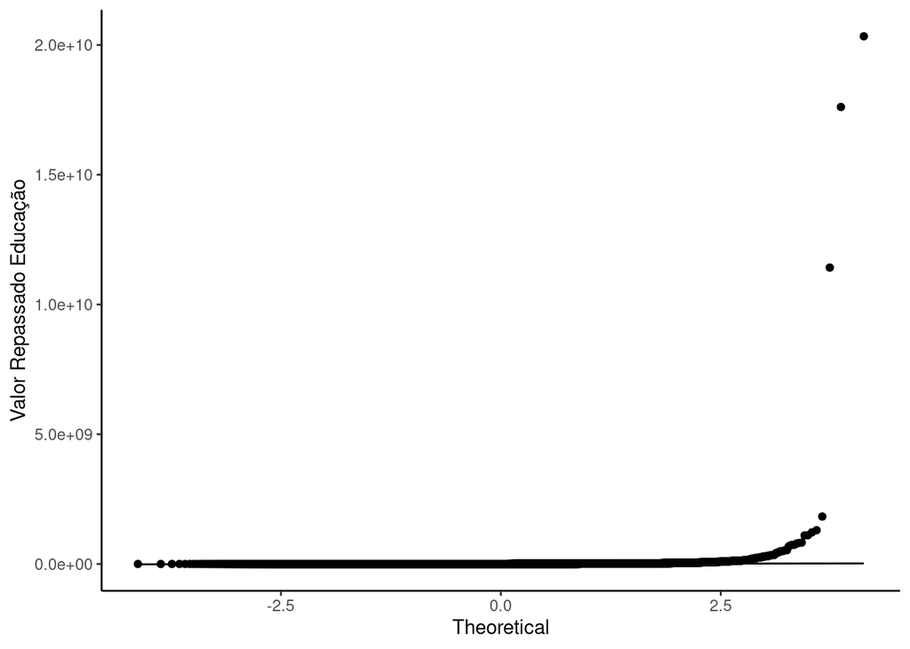

```r
# VALOR_REPASSADO_EDUCACAO

  ggqqplot(data$VALOR_REPASSADO_EDUCACAO, ylab = "Valor Repassado Educação") +
    theme_classic()
```

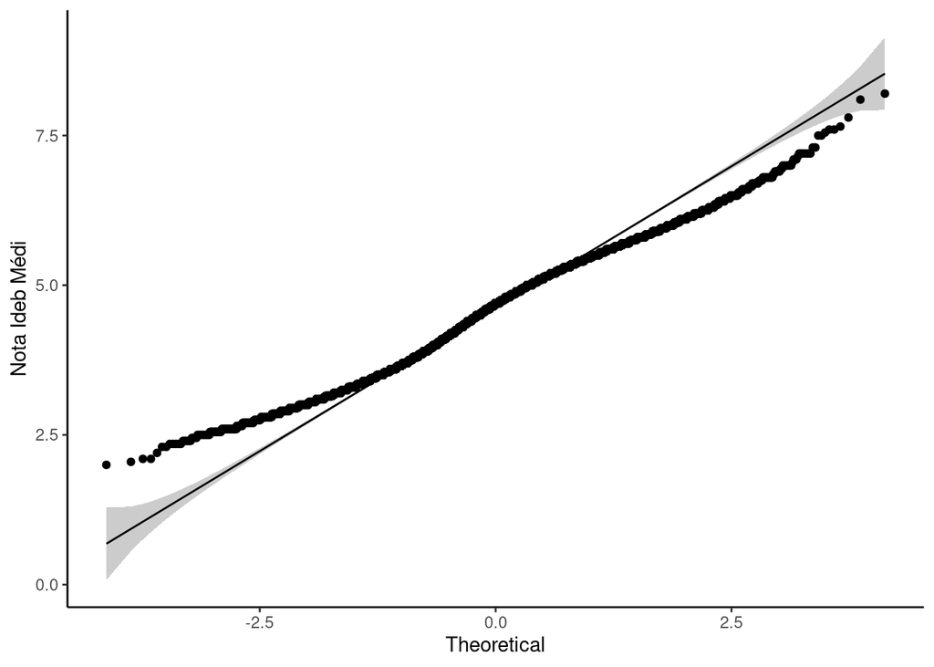

```r
# IDEB_NOTA
  ggqqplot(data$IDEB_MEDIA, ylab = "Nota Ideb Médi") + theme_classic()
```

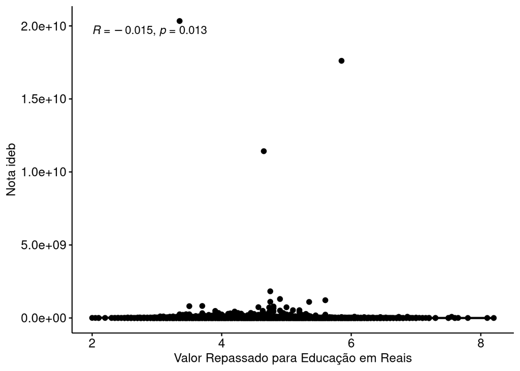

```r
ggscatter(data, x = "IDEB_MEDIA", y = "VALOR_REPASSADO_EDUCACAO",
          add = "reg.line", conf.int = TRUE,
          cor.coef = TRUE, cor.method = "pearson",
          xlab = "Valor Repassado para Educação em Reais", ylab = "Nota ideb")
```

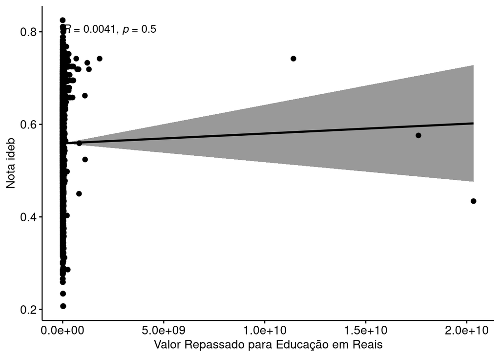

```r
ggscatter(data, x = "VALOR_REPASSADO_EDUCACAO", y = "IDH_EDUCACAO",
          add = "reg.line", conf.int = TRUE,
          cor.coef = TRUE, cor.method = "pearson",
          xlab = "Valor Repassado para Educação em Reais", ylab = "Nota ideb")
```

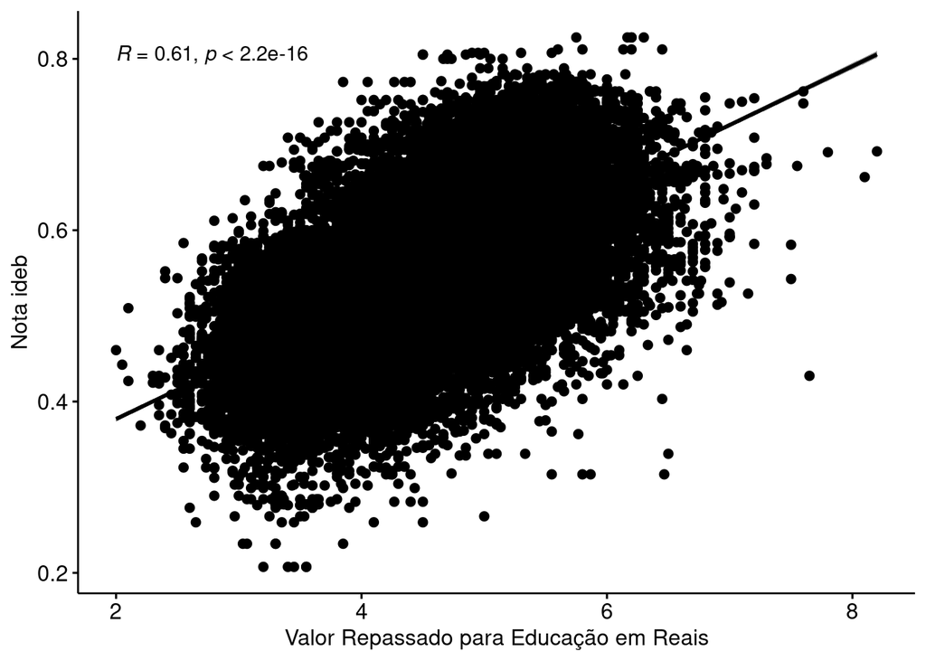

```r
ggscatter(data, x = "IDEB_MEDIA", y = "IDH_EDUCACAO",
          add = "reg.line", conf.int = TRUE,
          cor.coef = TRUE, cor.method = "pearson",
          xlab = "Valor Repassado para Educação em Reais", ylab = "Nota ideb")
```

Nesta visualização com `corrplot` não existe uma correlação forte do valor repassado para educação, com nenhuma outra variável, e exite uma boa correlação entre as notas do Ideb, e os medidores do IDH.

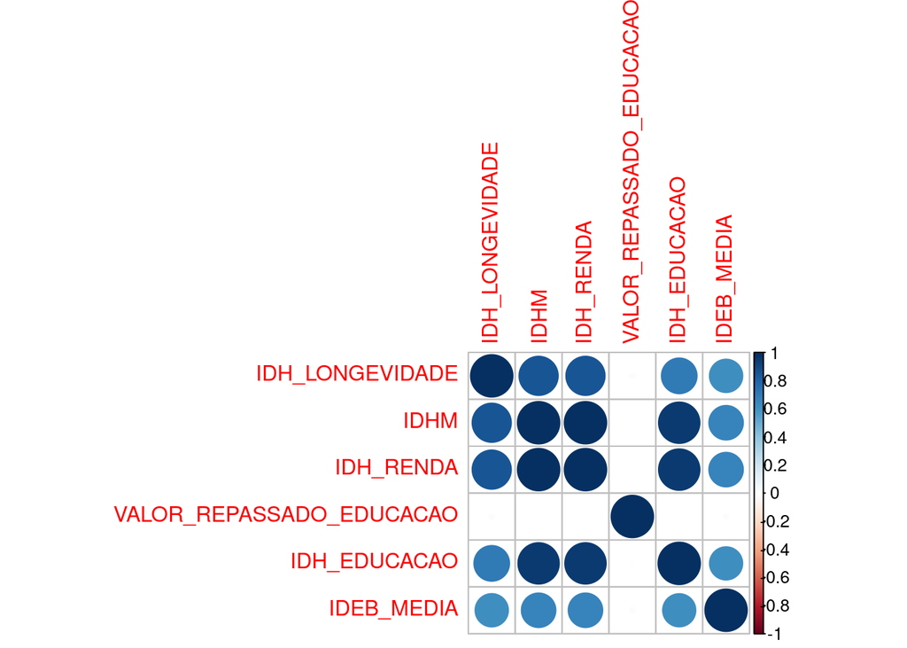

```r
correlations <- cor(data)
corrplot(correlations, method = "circle")
```

Já nesta visualização, podemos ver que existe uma correlação negativa baixa, dos valores repassados para educação, e a nota do Ideb.

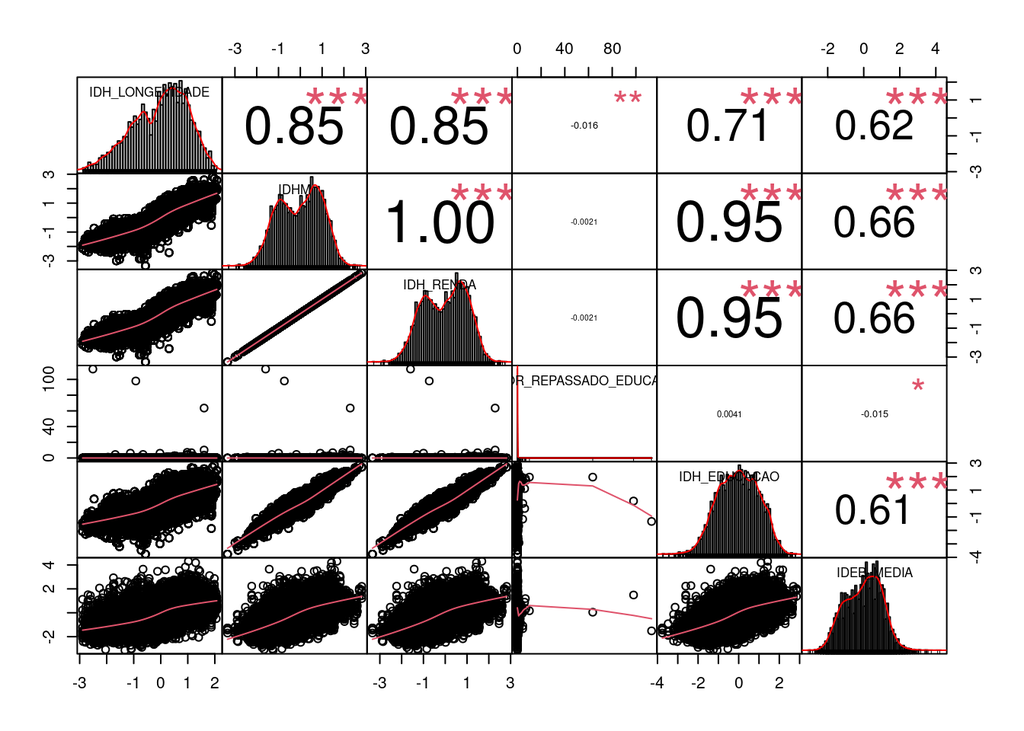

```r
data_scale <- scale(data)
chart.Correlation(data_scale, histogram=TRUE)
```

Pelo boxplot, existem alguns potenciais outliers nas notas do Ideb.

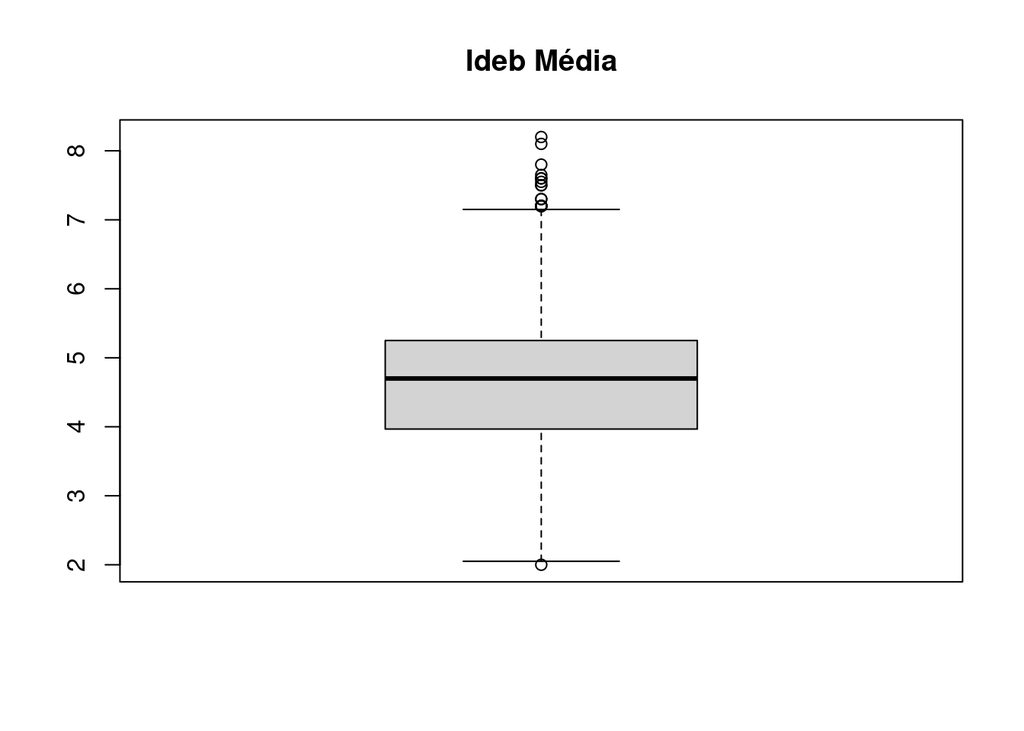

```r
boxplot(data$IDEB_MEDIA, main="Ideb Média")
```

```r
out_ideb <- boxplot.stats(data$IDEB_MEDIA)$out
out_ideb_ind <- which(data$IDEB_MEDIA %in% c(out_ideb))
data[out_ideb_ind, ]
```

| IDH_LONGEVIDADE | IDHM | IDH_RENDA | VALOR_REPASSADO_EDUCACAO | IDH_EDUCACAO | IDEB_MEDIA |
| --- | --- | --- | --- | --- | --- |
| 0.836 | 0.768 | 0.768 | 229539.4 | 0.708 | 7.20 |
| 0.847 | 0.780 | 0.780 | 399920.7 | 0.692 | 8.20 |
| 0.742 | 0.569 | 0.569 | 6434770.8 | 0.460 | 2.00 |
| 0.866 | 0.705 | 0.705 | 749308.1 | 0.583 | 7.50 |
| 0.796 | 0.663 | 0.663 | 147420.3 | 0.543 | 7.50 |
| 0.832 | 0.714 | 0.714 | 80142437.4 | 0.675 | 7.55 |
| 0.842 | 0.760 | 0.760 | 395877.5 | 0.691 | 7.80 |
| 0.848 | 0.764 | 0.764 | 112215.2 | 0.677 | 7.30 |
| 0.849 | 0.752 | 0.752 | 497210.7 | 0.630 | 7.20 |
| 0.849 | 0.744 | 0.744 | 703217.2 | 0.674 | 7.20 |

[output cut: 9 more lines]

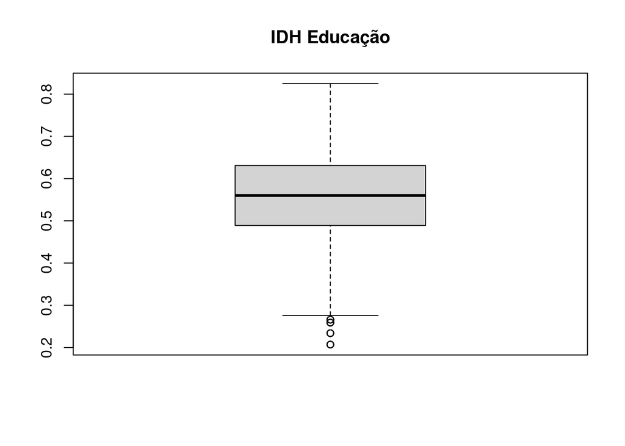

```r
boxplot(data$IDH_EDUCACAO, main="IDH Educação")
```

```r
out_idh <-boxplot.stats(data$IDH_EDUCACAO)$out
out_idh_ind <- which(data$IDH_EDUCACAO %in% c(out_idh))
data[out_idh_ind, ]
```

| IDH_LONGEVIDADE | IDHM | IDH_RENDA | VALOR_REPASSADO_EDUCACAO | IDH_EDUCACAO | IDEB_MEDIA |
| --- | --- | --- | --- | --- | --- |
| 0.733 | 0.450 | 0.450 | 3820918 | 0.259 | 2.650000 |
| 0.769 | 0.453 | 0.453 | 11195721 | 0.234 | 3.300000 |
| 0.772 | 0.477 | 0.477 | 2546200 | 0.266 | 5.000000 |
| 0.776 | 0.418 | 0.418 | 16379053 | 0.207 | 3.550000 |
| 0.733 | 0.450 | 0.450 | 6990699 | 0.259 | 3.350000 |
| 0.769 | 0.453 | 0.453 | 16230391 | 0.234 | 3.300000 |
| 0.772 | 0.477 | 0.477 | 3582650 | 0.266 | 3.500000 |
| 0.776 | 0.418 | 0.418 | 22025588 | 0.207 | 3.200000 |
| 0.733 | 0.450 | 0.450 | 7696374 | 0.259 | 4.100000 |
| 0.769 | 0.453 | 0.453 | 18217784 | 0.234 | 3.850000 |

[output cut: 10 more lines]

Essa visualização ficou meio estranha, não sei se teria que fazer algum ajuste:

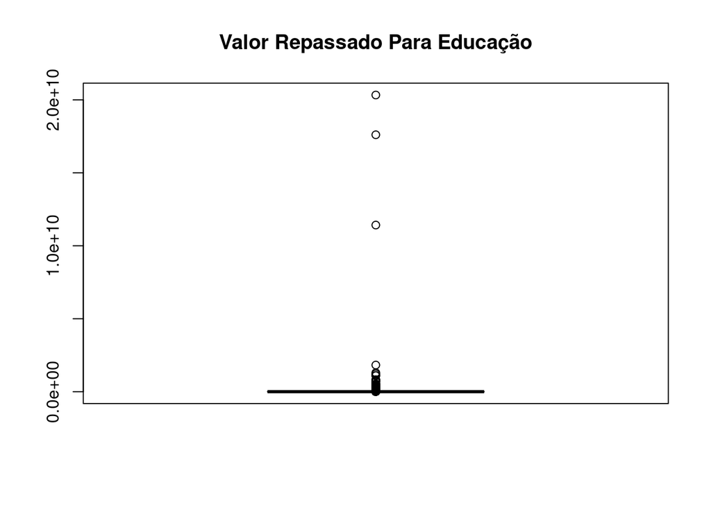

```r
boxplot(data$VALOR_REPASSADO_EDUCACAO, main="Valor Repassado Para Educação")
```

```r
out_repasse <-boxplot.stats(data$VALOR_REPASSADO_EDUCACAO)$out
out_repasse_ind <- which(data$VALOR_REPASSADO_EDUCACAO %in% c(out_repasse))
data[out_repasse_ind, ]
```

| IDH_LONGEVIDADE | IDHM | IDH_RENDA | VALOR_REPASSADO_EDUCACAO | IDH_EDUCACAO | IDEB_MEDIA |
| --- | --- | --- | --- | --- | --- |
| 0.688 | 0.570 | 0.570 | 17522192 | 0.477 | 3.450000 |
| 0.689 | 0.547 | 0.547 | 16771818 | 0.424 | 3.000000 |
| 0.693 | 0.554 | 0.554 | 23114698 | 0.472 | 3.600000 |
| 0.696 | 0.516 | 0.516 | 18618563 | 0.415 | 3.700000 |
| 0.699 | 0.506 | 0.506 | 25988942 | 0.359 | 3.300000 |
| 0.700 | 0.564 | 0.564 | 24696687 | 0.466 | 3.400000 |
| 0.700 | 0.550 | 0.550 | 40375481 | 0.452 | 3.700000 |
| 0.701 | 0.536 | 0.536 | 15985602 | 0.400 | 2.500000 |
| 0.702 | 0.557 | 0.557 | 18298164 | 0.404 | 3.150000 |
| 0.703 | 0.527 | 0.527 | 17076267 | 0.409 | 2.700000 |

[output cut: 2582 more lines]

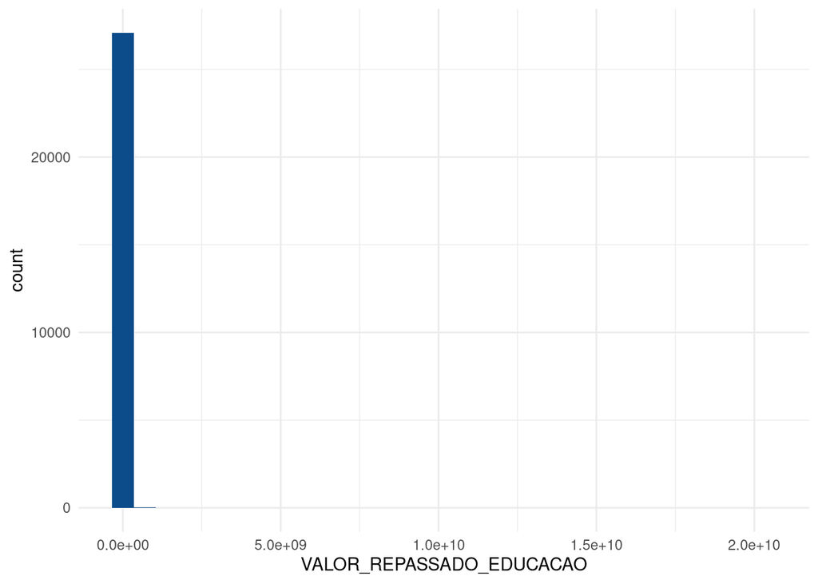

```r
ggplot(data) +
  aes(x = VALOR_REPASSADO_EDUCACAO) +
  geom_histogram(bins = 30L, fill = "#0c4c8a") +
  theme_minimal()
```

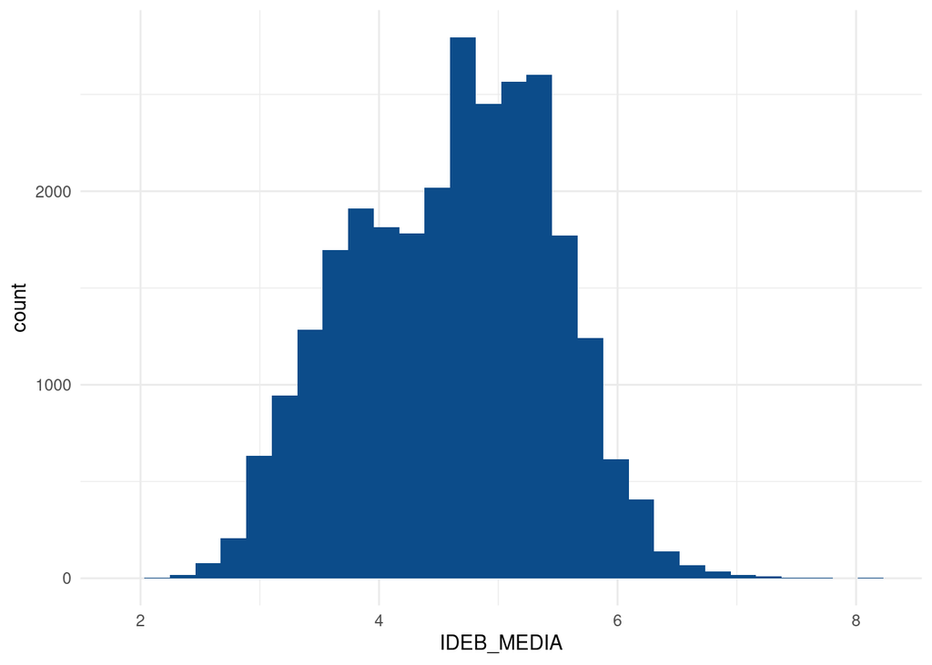

```r
ggplot(data) +
  aes(x = IDEB_MEDIA) +
  geom_histogram(bins = 30L, fill = "#0c4c8a") +
  theme_minimal()
```

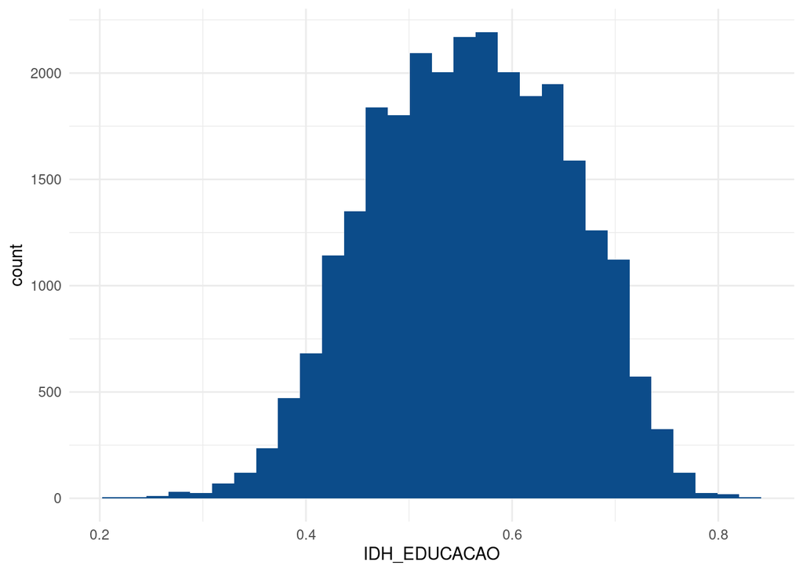

```r
ggplot(data) +
    aes(x = IDH_EDUCACAO) +
  geom_histogram(bins = 30L, fill = "#0c4c8a") +
  theme_minimal()
```